# R Notebook

Shad, Edin

december 1, 2016

### Scientific methodology and preformance evaluation

# Winter School, ENS Lyon

We start with looking at the data provided on the web page: http://mescal.imag.fr/membres/arnaud.legrand/teaching/2013/M2R_EP_archive_quicksort.tgz

We won’t focus on the particular implementation, although this is a very important part of the experiment, we leave it for the future work. We rather analyse the data, as we would do if somebody would give us implementation as black boxes which we query. One way to think about this, is that we do not compare in general which type of implementation works the best, but rather which out of three implementation is better for different sizes of arrays. So we turn towards determining when we should use one of these three algorithms to get faster running times.

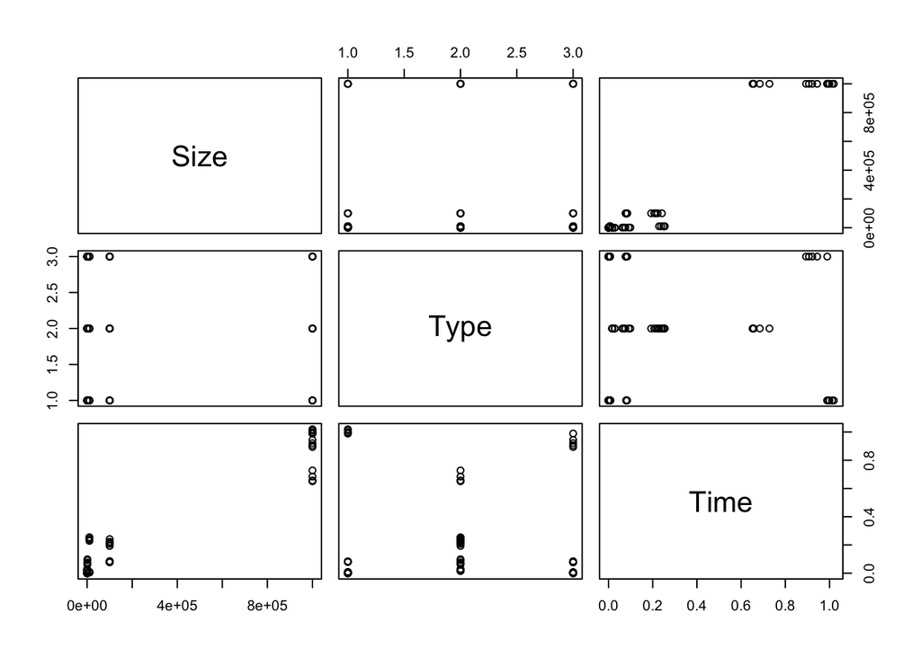

```r
data = read.csv("archive_quicksort/measurements.csv")
df = data.frame(data)
plot(df)
```

```r
summary(df)
```

```
##       Size                  Type         Time
##  Min.   :    100    Built-in  :25   Min.   :0.000039
##  1st Qu.:   1000    Parallel  :25   1st Qu.:0.000714
##  Median :  10000    Sequential:25   Median :0.076455
##  Mean   : 222220                    Mean   :0.223024
##  3rd Qu.: 100000                    3rd Qu.:0.239711
##  Max.   :1000000                    Max.   :1.019417
```

The above plot didn’t say much. We observe that Size and Type are discrete variables and that Time should be assumed as continous. In order to see more, lets separate data according to the algorithm used.

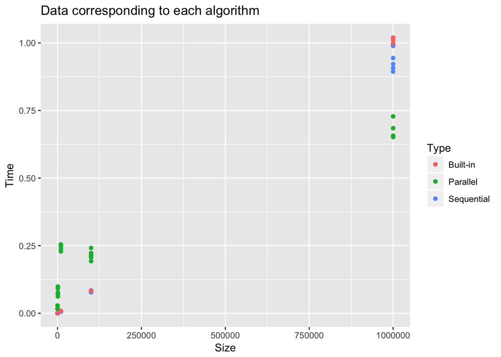

```r
library(ggplot2)
ggplot(df, aes(x = Size, y = Time, colour = Type,  group = Type)) + geom_point() + ggtitle("Data corresponding to each algorithm")
```

Obsearvtions: sizes for which the algorithms were tested are quite scarce and we can not conclude much. If we would have just this data, we could try to fit linear regression for each of the algorithms. Even if the results of linear regresion return good values in terms of R-value and p-values, we could be missing some strange behaviours since our data is so scarce. In any way we do the linear regresion for data of each algorithm. Before that, we plot again data of each algorithm separately just to see if they look linear.

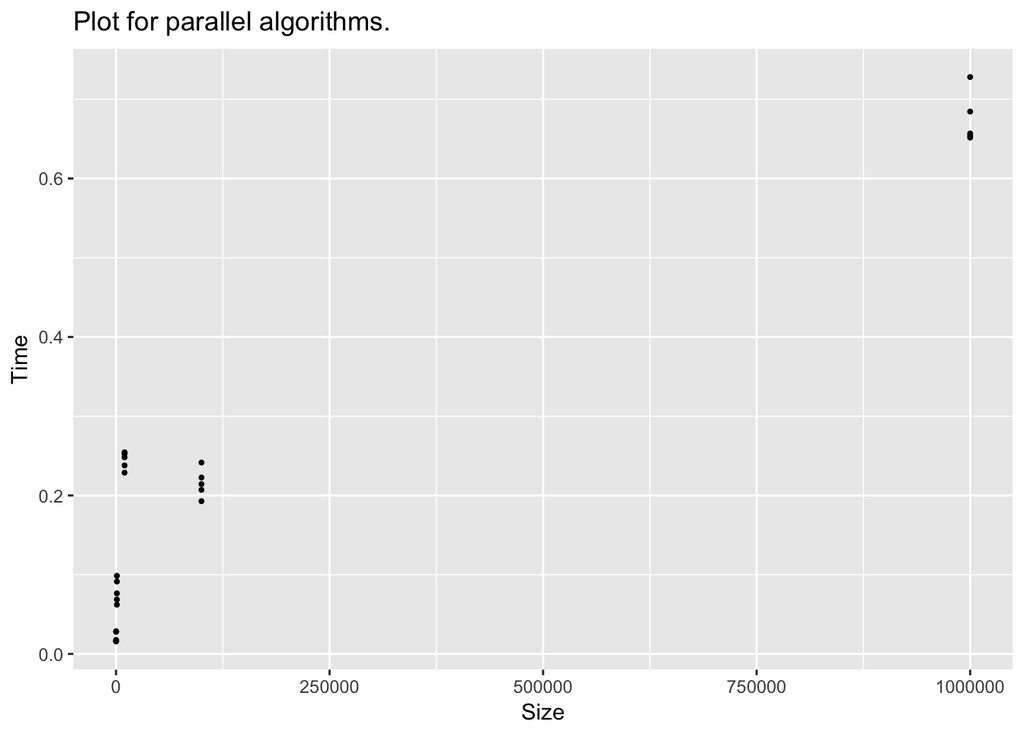

```r
para = df[df$Type == " Parallel",]
sequ = df[df$Type == " Sequential",]
builtIn = df[df$Type == " Built-in",]

ggplot(para, aes(x = Size, y= Time)) + geom_point(size = 0.7) + ggtitle("Plot for parallel algorithms.")
```

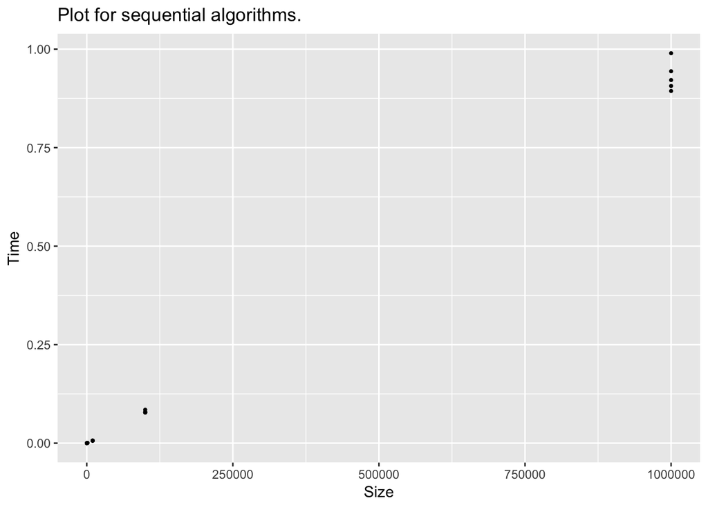

```r
ggplot(sequ, aes(x = Size, y= Time)) + geom_point(size = 0.7) + ggtitle("Plot for sequential algorithms.")
```

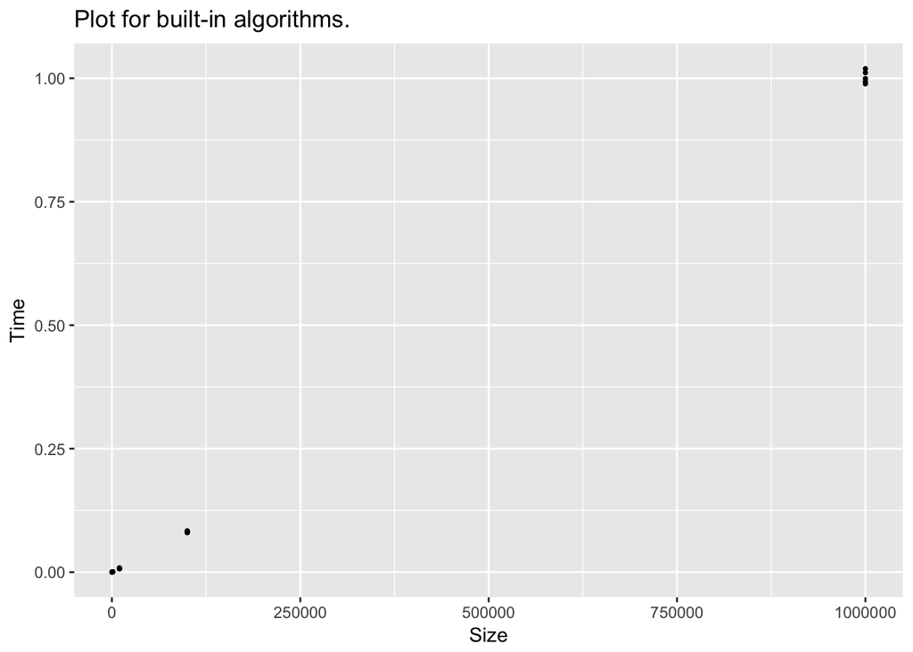

```r
ggplot(builtIn, aes(x = Size, y= Time)) + geom_point(size = 0.7) + ggtitle("Plot for built-in algorithms.")
```

With exception of one outliner for parallel algorithm, we see that data resemble a linear function

```r
regp = lm(data = para, Time ~ Size)
summary(regp)
```

```
##
## Call:
## lm(formula = Time ~ Size, data = para)
##
## Residuals:
##      Min       1Q   Median       3Q      Max
## -0.10783 -0.05543 -0.02297  0.04831  0.12536
##
## Coefficients:
##              Estimate Std. Error t value Pr(>|t|)
## (Intercept) 1.235e-01  1.812e-02   6.816 5.96e-07 ***
## Size        5.563e-07  4.032e-08  13.795 1.30e-12 ***
## ---
## Signif. codes:  0 '***' 0.001 '**' 0.01 '*' 0.05 '.' 0.1 ' ' 1
##
## Residual standard error: 0.07877 on 23 degrees of freedom
## Multiple R-squared:  0.8922, Adjusted R-squared:  0.8875
## F-statistic: 190.3 on 1 and 23 DF,  p-value: 1.304e-12
```

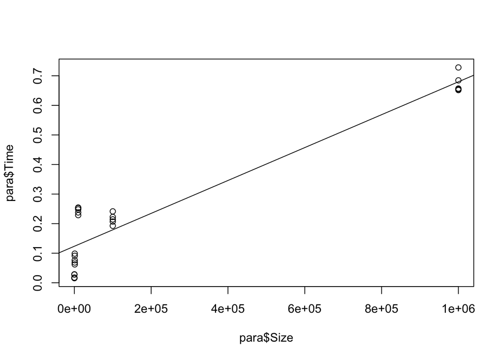

```r
plot(x = para$Size,y = para$Time)
abline(regp)
```

Results of linear fit for parallel algorithm seems quite strong for this data.

```r
regq = lm(data = sequ, Time ~ Size)
summary(regq)
```

```
##
## Call:
## lm(formula = Time ~ Size, data = sequ)
##
## Residuals:
##       Min        1Q    Median        3Q       Max
## -0.036347 -0.008607  0.001317  0.004038  0.059532
##
## Coefficients:
##               Estimate Std. Error t value Pr(>|t|)
## (Intercept) -4.092e-03  3.822e-03  -1.071    0.295
## Size         9.343e-07  8.504e-09 109.864   <2e-16 ***
## ---
## Signif. codes:  0 '***' 0.001 '**' 0.01 '*' 0.05 '.' 0.1 ' ' 1
##
## Residual standard error: 0.01661 on 23 degrees of freedom
## Multiple R-squared:  0.9981, Adjusted R-squared:  0.998
## F-statistic: 1.207e+04 on 1 and 23 DF,  p-value: < 2.2e-16
```

```r
par(mfrow~c(1,1))
```

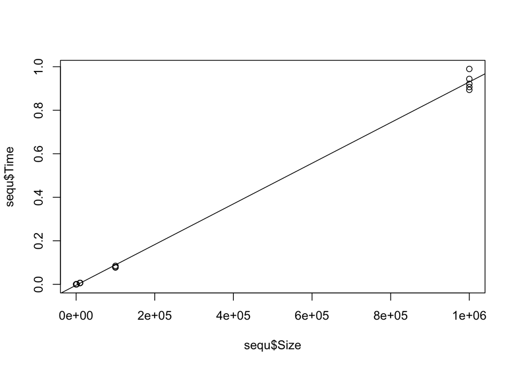

```r
plot(x = sequ$Size,y = sequ$Time)
abline(regq)
```

Linear fit for the sequential model

```r
regb = lm(data = builtIn, Time ~ Size)
summary(regb)
```

```
##
## Call:
## lm(formula = Time ~ Size, data = builtIn)
##
## Residuals:
##       Min        1Q    Median        3Q       Max
## -0.015615 -0.007997  0.003712  0.005146  0.018362
##
## Coefficients:
##               Estimate Std. Error t value Pr(>|t|)
## (Intercept) -5.206e-03  2.107e-03   -2.47   0.0213 *
## Size         1.006e-06  4.689e-09  214.62   <2e-16 ***
## ---
## Signif. codes:  0 '***' 0.001 '**' 0.01 '*' 0.05 '.' 0.1 ' ' 1
##
## Residual standard error: 0.009159 on 23 degrees of freedom
## Multiple R-squared:  0.9995, Adjusted R-squared:  0.9995
## F-statistic: 4.606e+04 on 1 and 23 DF,  p-value: < 2.2e-16
```

```r
par(mfrow~c(1,1))
```

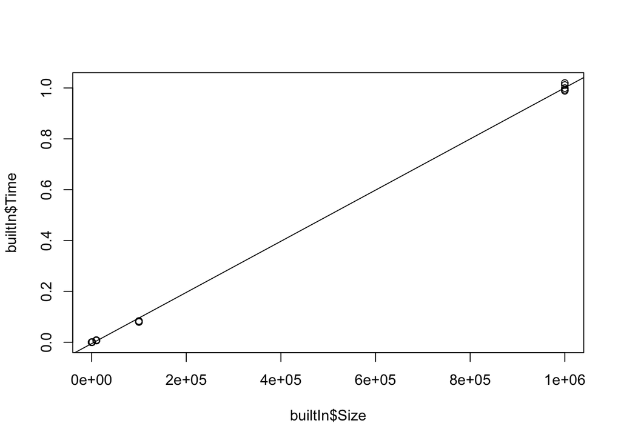

```r
plot(x = builtIn$Size,y = builtIn$Time)
abline(regb)
```

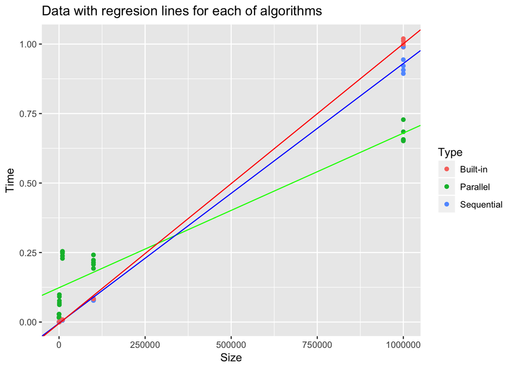

```r
ggplot(df, aes(x = Size, y = Time, colour = Type,  group = Type)) + geom_point() + ggtitle("Data with regresion lines for each of algorithms") + geom_abline(intercept = coef(regp)["(Intercept)"], slope = coef(regp)["Size"], colour = "green" ) +geom_abline(intercept = coef(regq)["(Intercept)"], slope = coef(regq)["Size"], colour = "blue" ) + geom_abline(intercept = coef(regb)["(Intercept)"], slope = coef(regb)["Size"], colour = "red" )
```

```r
dataEdin = read.csv("MyData/measurements.csv")
dE = data.frame(dataEdin)
summary(dE)
```

```
##       Size                  Type         Time
##  Min.   :    100    Built-in  :55   Min.   :0.000009
##  1st Qu.:   1000    Parallel  :55   1st Qu.:0.001565
##  Median :  50000    Sequential:55   Median :0.051495
##  Mean   : 242418                    Mean   :0.100817
##  3rd Qu.: 500000                    3rd Qu.:0.211804
##  Max.   :1000000                    Max.   :0.309712
```

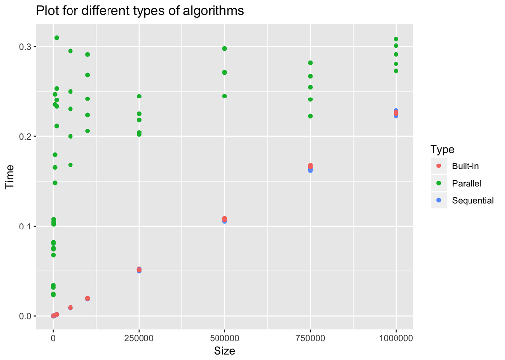

```r
ggplot(dE, aes(x = Size, y = Time, colour = Type,  group = Type)) + geom_point() + ggtitle("Plot for different types of algorithms")
```

We observe that the paralel algorithm shows very slow running time for smaller arrays. But it seems that it will be better after some big enough size. That is way we for the moment stop here, and try to get more data for the biggest sizes of arrays. But first, let us see what happens with the same procedure on different arhitecture.

```r
dataShad = read.csv("ShadMeasurements.csv")
dS = data.frame(dataShad)
summary(dS)
```

```
##       Size                  Type         Time
##  Min.   :    100    Built-in  :55   Min.   :0.000007
##  1st Qu.:   1000    Parallel  :55   1st Qu.:0.001457
##  Median :  50000    Sequential:55   Median :0.029517
##  Mean   : 242418                    Mean   :0.073540
##  3rd Qu.: 500000                    3rd Qu.:0.131701
##  Max.   :1000000                    Max.   :0.326254
```

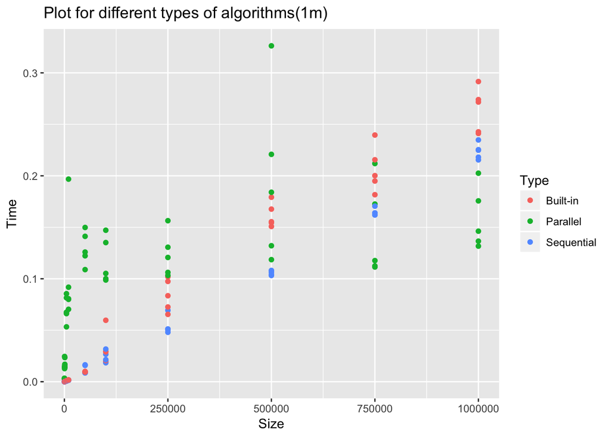

```r
ggplot(dS, aes(x = Size, y = Time, colour = Type,  group = Type)) + geom_point() + ggtitle("Plot for different types of algorithms(1m)")
```

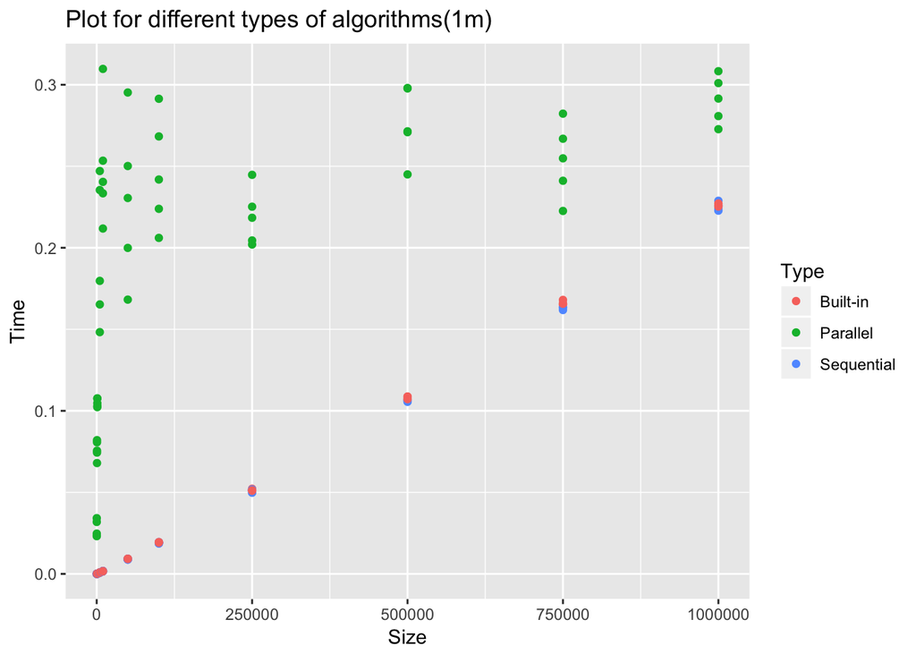

```r
ggplot(dE, aes(x = Size, y = Time, colour = Type,  group = Type)) + geom_point() + ggtitle("Plot for different types of algorithms(1m)")
```

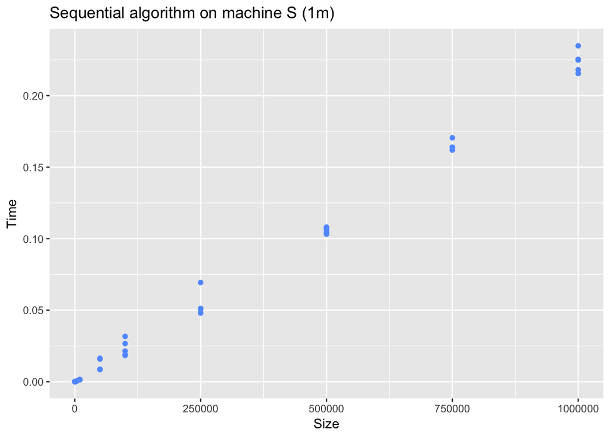

```r
ggplot(dS[dS$Type == " Sequential",],  aes(x = Size, y = Time, colour = Type,  group = Type)) + geom_point(colour="#619CFF") + ggtitle("Sequential algorithm on machine S (1m)")
```

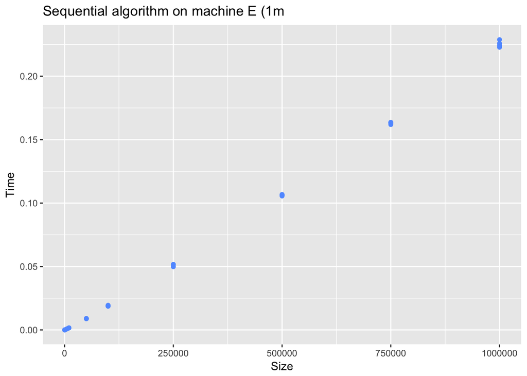

```r
ggplot(dE[dE$Type == " Sequential",] , aes(x = Size, y = Time, colour = Type,  group = Type)) + geom_point(colour="#619CFF") + ggtitle("Sequential algorithm on machine E (1m")
```

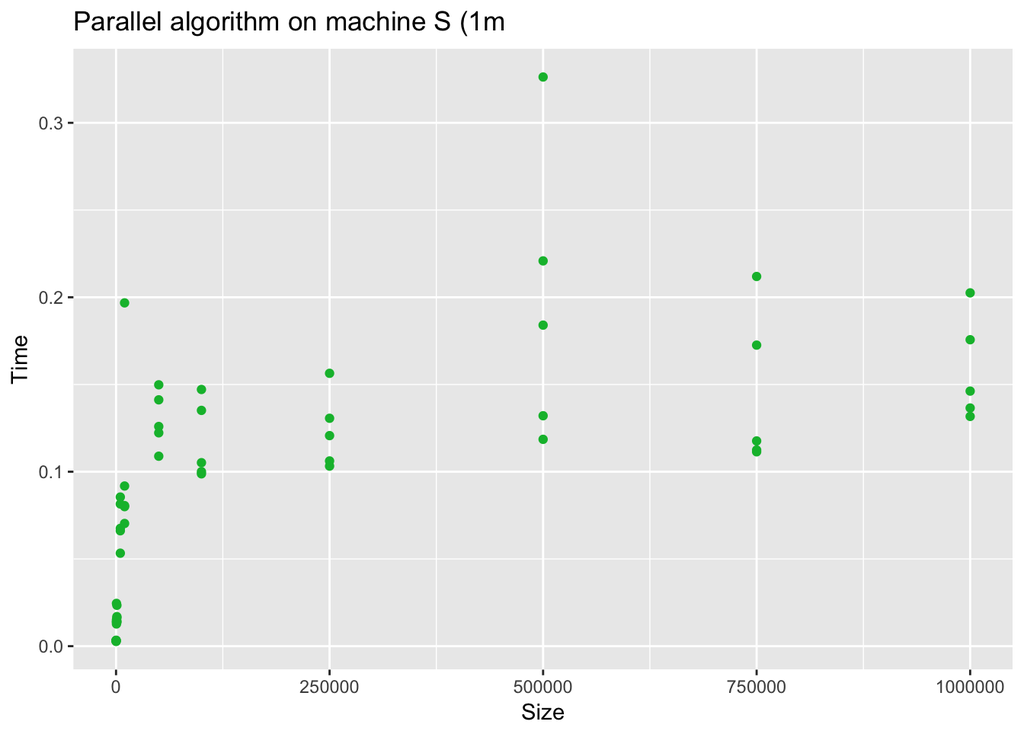

```r
ggplot(dS[dS$Type == " Parallel",],  aes(x = Size, y = Time, colour = Type,  group = Type)) + geom_point(colour="#00BA38") + ggtitle("Parallel algorithm on machine S (1m")
```

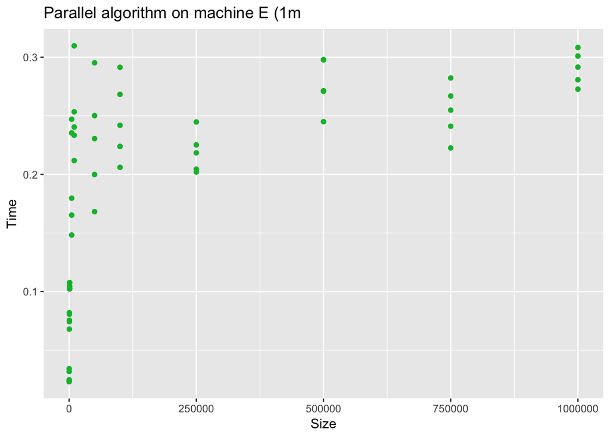

```r
ggplot(dE[dE$Type == " Parallel",] , aes(x = Size, y = Time, colour = Type,  group = Type)) + geom_point(colour="#00BA38") + ggtitle("Parallel algorithm on machine E (1m")
```

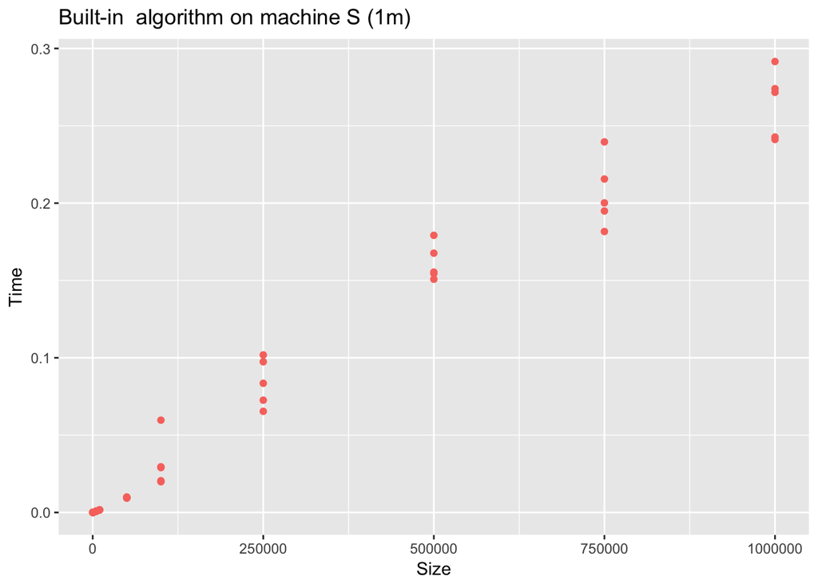

```r
ggplot(dS[dS$Type == " Built-in",],  aes(x = Size, y = Time, colour = Type,  group = Type)) + geom_point(colour = "#F8766D") + ggtitle("Built-in  algorithm on machine S (1m)")
```

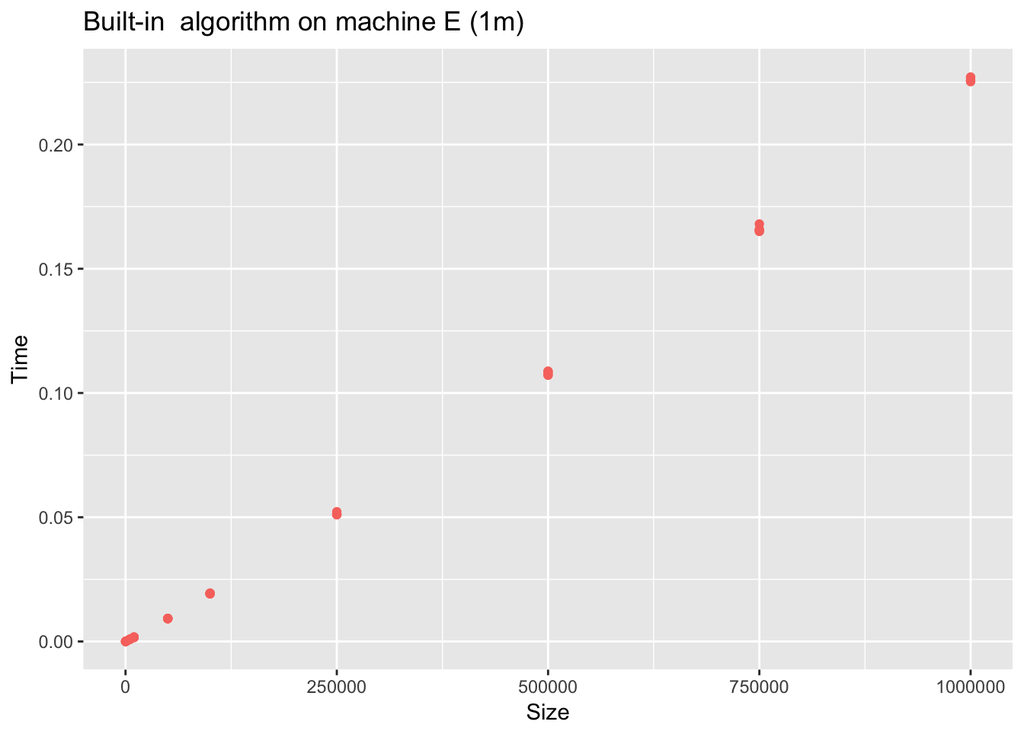

```r
ggplot(dE[dE$Type == " Built-in",] , aes(x = Size, y = Time, colour = Type,  group = Type)) + geom_point(colour = "#F8766D") + ggtitle("Built-in  algorithm on machine E (1m)")
```

We observe that in both cases the parallel algorithm doesn’t follow linear scaling, while both sequential and built-in algorithm show linear increase of execution time with the size. We also decide that for a better estimation we need to increase the maximum size. We move the maximum up to two milion.

```r
dataEdin2 = read.csv("MyData2milion/measurements.csv")
dE2 = data.frame(dataEdin2)
summary(dE2)
```

```
##       Size                  Type         Time
##  Min.   :    100    Built-in  :75   Min.   :0.000009
##  1st Qu.:   5000    Parallel  :75   1st Qu.:0.009231
##  Median : 250000    Sequential:75   Median :0.162244
##  Mean   : 611107                    Mean   :0.174722
##  3rd Qu.:1250000                    3rd Qu.:0.294626
##  Max.   :2000000                    Max.   :0.499404
```

We again plot it, to get more intution.

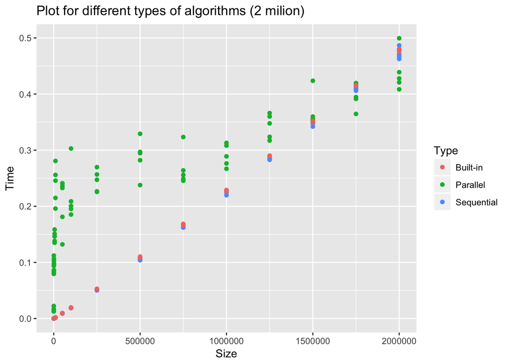

```r
ggplot(dE2, aes(x = Size, y = Time, colour = Type,  group = Type)) + geom_point() + ggtitle("Plot for different types of algorithms (2 milion)")
```

```r
dataShad2 = read.csv("ShadMeasurements2.csv")
dS2 = data.frame(dataShad2)
summary(dS2)
```

```
##       Size                  Type         Time
##  Min.   :    100    Built-in  :75   Min.   :0.000008
##  1st Qu.:   5000    Parallel  :75   1st Qu.:0.008685
##  Median : 250000    Sequential:75   Median :0.108788
##  Mean   : 611107                    Mean   :0.141720
##  3rd Qu.:1250000                    3rd Qu.:0.225626
##  Max.   :2000000                    Max.   :0.552768
```

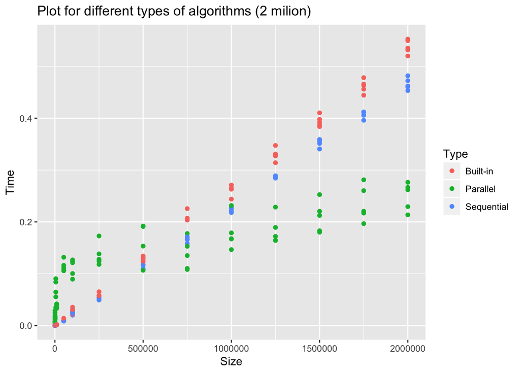

```r
ggplot(dS2, aes(x = Size, y = Time, colour = Type,  group = Type)) + geom_point() + ggtitle("Plot for different types of algorithms (2 milion)")
```

We see again that the Parallel algorithm does not really follow a linear model but we try it noonetheles.

```r
paraS2 = dS2[dS2$Type == " Parallel",]
regpS2 <- lm(data=paraS2, Time~Size)
summary(regpS2)
```

```
##
## Call:
## lm(formula = Time ~ Size, data = paraS2)
##
## Residuals:
##       Min        1Q    Median        3Q       Max
## -0.058312 -0.032083 -0.002933  0.037808  0.085910
##
## Coefficients:
##              Estimate Std. Error t value Pr(>|t|)
## (Intercept) 6.149e-02  6.094e-03   10.09 1.74e-15 ***
## Size        1.020e-07  6.607e-09   15.43  < 2e-16 ***
## ---
## Signif. codes:  0 '***' 0.001 '**' 0.01 '*' 0.05 '.' 0.1 ' ' 1
##
## Residual standard error: 0.03953 on 73 degrees of freedom
## Multiple R-squared:  0.7654, Adjusted R-squared:  0.7622
## F-statistic: 238.2 on 1 and 73 DF,  p-value: < 2.2e-16
```

```r
regpS2log <- lm(data=paraS2, Time~log(Size))
summary(regpS2log)
```

```
##
## Call:
## lm(formula = Time ~ log(Size), data = paraS2)
##
## Residuals:
##       Min        1Q    Median        3Q       Max
## -0.069313 -0.024475 -0.005256  0.022168  0.084333
##
## Coefficients:
##              Estimate Std. Error t value Pr(>|t|)
## (Intercept) -0.132906   0.014009  -9.487 2.28e-14 ***
## log(Size)    0.022944   0.001204  19.060  < 2e-16 ***
## ---
## Signif. codes:  0 '***' 0.001 '**' 0.01 '*' 0.05 '.' 0.1 ' ' 1
##
## Residual standard error: 0.03339 on 73 degrees of freedom
## Multiple R-squared:  0.8327, Adjusted R-squared:  0.8304
## F-statistic: 363.3 on 1 and 73 DF,  p-value: < 2.2e-16
```

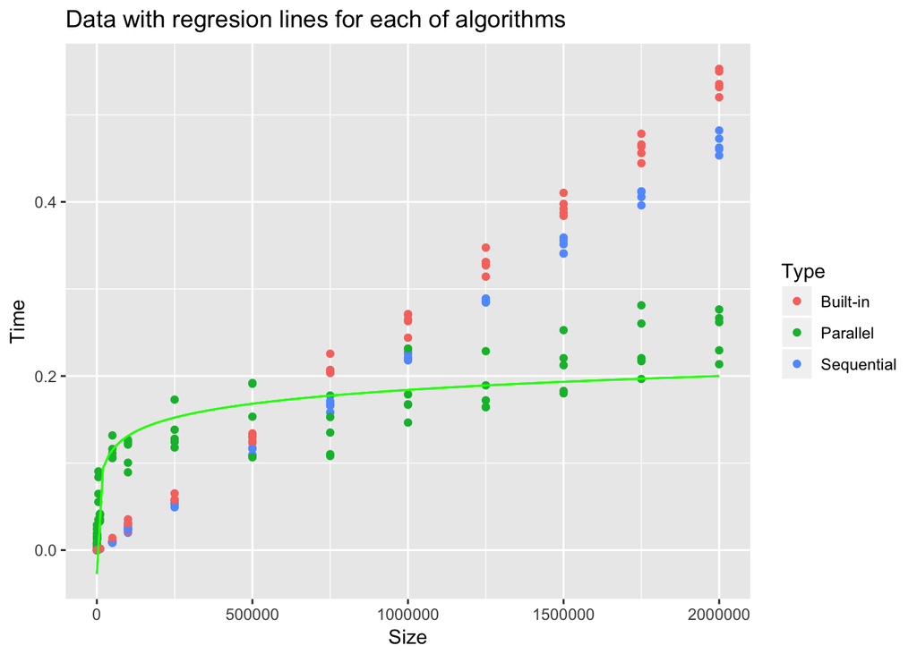

```r
para2 = dS2[dS2$Type == "Parallel",]
test <- function(x) {coef(regpS2log)["log(Size)"]*log(x) + coef(regpS2log)["(Intercept)"]}
ggplot(dS2, aes(x = Size, y = Time, colour = Type,  group = Type)) + geom_point() + ggtitle("Data with regresion lines for each of algorithms") + stat_function(fun=test,color="green")
```

```r
test1 <- rbind(dS2, dE2)
paraComb = test1[test1$Type == " Parallel",]
regComb <- lm(data=paraComb, Time~log(Size))
regLin <- lm(data=paraComb, Time~Size)
summary(regLin)
```

```
##
## Call:
## lm(formula = Time ~ Size, data = paraComb)
##
## Residuals:
##      Min       1Q   Median       3Q      Max
## -0.14302 -0.07508 -0.00723  0.06553  0.18305
##
## Coefficients:
##              Estimate Std. Error t value Pr(>|t|)
## (Intercept) 1.074e-01  8.772e-03   12.25   <2e-16 ***
## Size        1.246e-07  9.510e-09   13.10   <2e-16 ***
## ---
## Signif. codes:  0 '***' 0.001 '**' 0.01 '*' 0.05 '.' 0.1 ' ' 1
##
## Residual standard error: 0.08048 on 148 degrees of freedom
## Multiple R-squared:  0.537,  Adjusted R-squared:  0.5338
## F-statistic: 171.6 on 1 and 148 DF,  p-value: < 2.2e-16
```

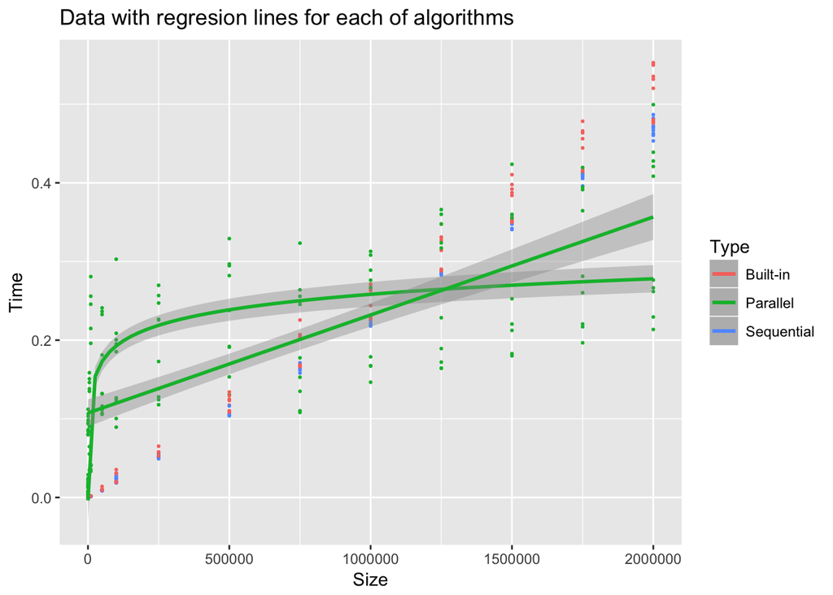

```r
test <- function(x) {coef(regComb)["log(Size)"]*log(x) + coef(regComb)["(Intercept)"]}
ggplot(test1, aes(x = Size, y = Time, colour = Type,  group = Type)) + geom_point(size=0.4) + ggtitle("Data with regresion lines for each of algorithms") + geom_smooth(data = subset(test1, Type == " Parallel"), method = "lm", formula = y ~ log(x)) + geom_smooth(data=subset(test1, Type == " Parallel"), method = "lm", formula = y~x)
```

```r
summary(regComb)
```

```
##
## Call:
## lm(formula = Time ~ log(Size), data = paraComb)
##
## Residuals:
##       Min        1Q    Median        3Q       Max
## -0.141973 -0.060549  0.004071  0.050589  0.221361
##
## Coefficients:
##              Estimate Std. Error t value Pr(>|t|)
## (Intercept) -0.134809   0.022144  -6.088 9.38e-09 ***
## log(Size)    0.028456   0.001903  14.955  < 2e-16 ***
## ---
## Signif. codes:  0 '***' 0.001 '**' 0.01 '*' 0.05 '.' 0.1 ' ' 1
##
## Residual standard error: 0.07463 on 148 degrees of freedom
## Multiple R-squared:  0.6018, Adjusted R-squared:  0.5991
## F-statistic: 223.6 on 1 and 148 DF,  p-value: < 2.2e-16
```

We combined the data from the two computers but it does not really make sense, as expected we obtain low R-squared values and p-values.

```r
regpS2test <- lm(data=paraS2, Time~Size)
summary(regpS2test)
```

```
##
## Call:
## lm(formula = Time ~ Size, data = paraS2)
##
## Residuals:
##       Min        1Q    Median        3Q       Max
## -0.058312 -0.032083 -0.002933  0.037808  0.085910
##
## Coefficients:
##              Estimate Std. Error t value Pr(>|t|)
## (Intercept) 6.149e-02  6.094e-03   10.09 1.74e-15 ***
## Size        1.020e-07  6.607e-09   15.43  < 2e-16 ***
## ---
## Signif. codes:  0 '***' 0.001 '**' 0.01 '*' 0.05 '.' 0.1 ' ' 1
##
## Residual standard error: 0.03953 on 73 degrees of freedom
## Multiple R-squared:  0.7654, Adjusted R-squared:  0.7622
## F-statistic: 238.2 on 1 and 73 DF,  p-value: < 2.2e-16
```

```r
regpS2t <- lm(data=paraS2, Time~log(Size)+Size)
summary(regpS2t)
```

```
##
## Call:
## lm(formula = Time ~ log(Size) + Size, data = paraS2)
##
## Residuals:
##      Min       1Q   Median       3Q      Max
## -0.05694 -0.01822 -0.00141  0.01667  0.05525
##
## Coefficients:
##               Estimate Std. Error t value Pr(>|t|)
## (Intercept) -7.114e-02  1.411e-02  -5.043 3.31e-06 ***
## log(Size)    1.478e-02  1.507e-03   9.807 6.69e-15 ***
## Size         4.837e-08  6.986e-09   6.924 1.53e-09 ***
## ---
## Signif. codes:  0 '***' 0.001 '**' 0.01 '*' 0.05 '.' 0.1 ' ' 1
##
## Residual standard error: 0.02605 on 72 degrees of freedom
## Multiple R-squared:  0.8996, Adjusted R-squared:  0.8968
## F-statistic: 322.4 on 2 and 72 DF,  p-value: < 2.2e-16
```

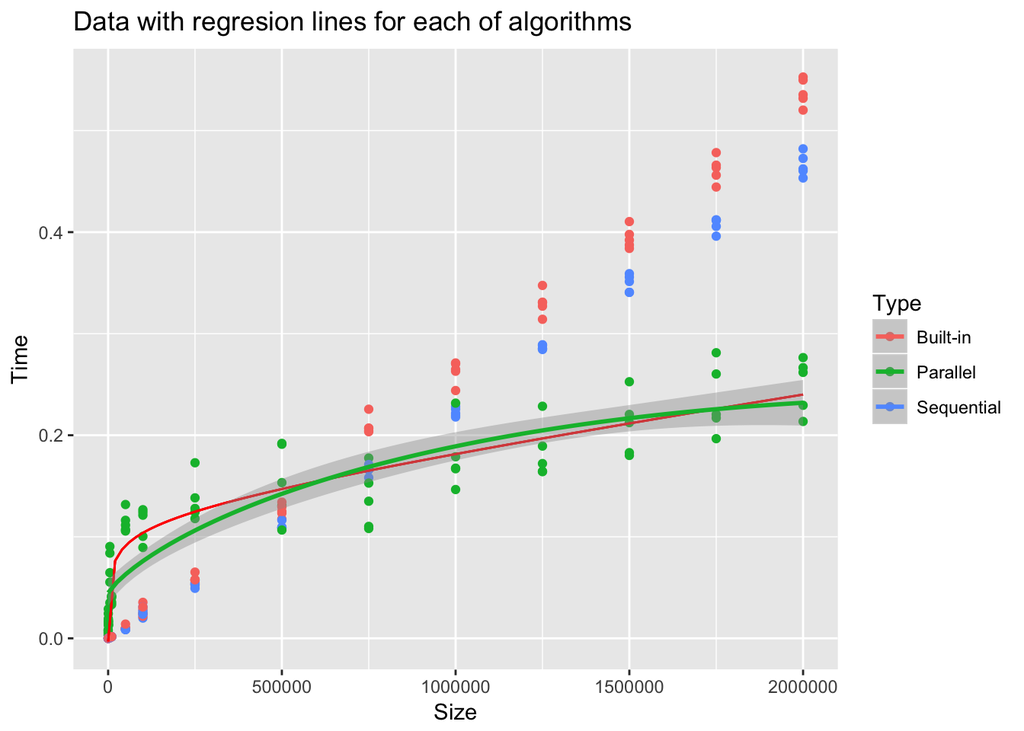

```r
para2 = dS2[dS2$Type == "Parallel",]
test <- function(x) {coef(regpS2t)["log(Size)"]*log(x) + coef(regpS2t)["(Intercept)"]+coef(regpS2t)["Size"]*x}
ggplot(dS2, aes(x = Size, y = Time, colour = Type,  group = Type)) + geom_point() + ggtitle("Data with regresion lines for each of algorithms") + stat_function(fun=test,color="red") + geom_smooth(data=subset(dS2, Type == " Parallel"), method = "lm", formula = y~I(x*log(x))+x)
```

```r
regpS23 <- lm(data=paraS2, Time~I(log(Size)*Size)+Size)
summary(regpS23)
```

```
##
## Call:
## lm(formula = Time ~ I(log(Size) * Size) + Size, data = paraS2)
##
## Residuals:
##       Min        1Q    Median        3Q       Max
## -0.060640 -0.029721 -0.008666  0.033341  0.068815
##
## Coefficients:
##                       Estimate Std. Error t value Pr(>|t|)
## (Intercept)          4.477e-02  6.330e-03   7.073 8.10e-10 ***
## I(log(Size) * Size) -7.317e-08  1.501e-08  -4.876 6.26e-06 ***
## Size                 1.155e-06  2.161e-07   5.346 1.01e-06 ***
## ---
## Signif. codes:  0 '***' 0.001 '**' 0.01 '*' 0.05 '.' 0.1 ' ' 1
##
## Residual standard error: 0.03451 on 72 degrees of freedom
## Multiple R-squared:  0.8236, Adjusted R-squared:  0.8187
## F-statistic: 168.1 on 2 and 72 DF,  p-value: < 2.2e-16
```

The model xlog(x)+x provides a good fit for our data. Furthermore it also makes sense because we expect the model to behave like a O(xlog(x)) function where xlog(x) is the leading term. However we might have some other term who also dictates the running time of the function and changes the curve. For our model we chose this other term to be x which provides us with the green curve on the above plot. The model logx + x obtains better values but the model doesn’t make sense and thus could just be a good model for this data (overfitting).